# Does the movement of students to a different region of England for education associate with increased lonliness in their county or region of origin?

# 1 Data visualisation

This work was undertaken as part of a data challenge organised by the Jean Golding Institute for Data-Intensive Research at the University of Bristol and ONS. The team was made up of:

- Axel Montout
- Lucy Vass
- Luke McGuinness

## 1.1 Visualization of the data provided for the Loneliness data challenge.

[figure not shown]

*Screen capture of the visualization website.*

In an attempt to better understand the data provided a visualization program displaying the geographic and time distrubution of the zscore provided was developped. The program takes form as a website accessible at the following web address http://51.38.69.55/.  
**The program is hosted on a low performance private server. Acces to this server provided by the link above is for basic demonstration purposes. For proprer use and user interaction the program should be hosted on an appropriate server.**  
The source code is available at https://github.com/mcguinlu/JGI-Comp/tree/master/visualization.

This document explains the different features of the site.

## 1.2 Control panel

Located in the upper section of the site the control panel allows to select what information will be displayed in the lower section.

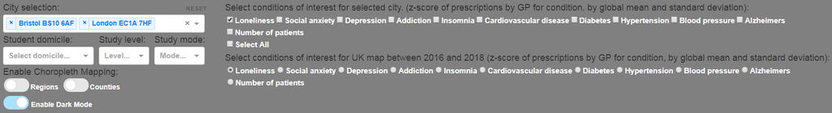

## 1.3 Bar graph

In the lower section on the right side is displayed the bar graph(s) representing the data of the cities selected in the control panel where one or multiple condition of interest can as well be selected. The x axis shows the year of the data collection. The y axis displays the zscore value(s) of the selected condition(s).

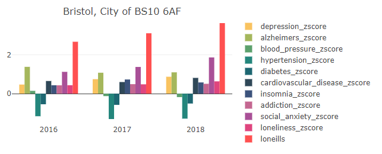

*Bar graph for the city of Bristol and for the folowing conditions: loneliness, social anxiety, depression, addiction, insomnia, cardiovascular disease diabetes, hypertension, blood pressure, alzheimers.*

## 1.4 Map

In the lower section on the left is displayed 3 maps. They each displays the data for one year. The available years are 2016, 2017 and 2018. The data for only one condition can be displayed at a time. Different visualization mode are available including choropleth map of the regions or counties in England which uses gradiant coloring of the location. In addition, Scatter map which distinguishes data using different colors and sizes of the data points.

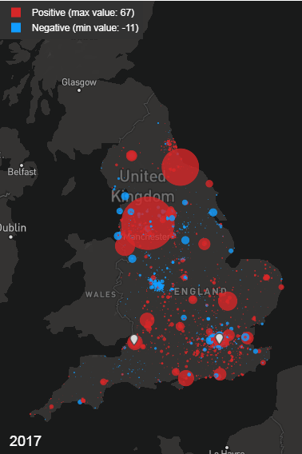

*The figure above shows the loneliness zscore at every recorded location in 2017. The size of the dot is representative of the zcore value. A negative zscore is represented by a blue dot whereas a red dot represent a positive value. In this mode the raw data provided is displayed. Their is no alteration or processing of the data.*

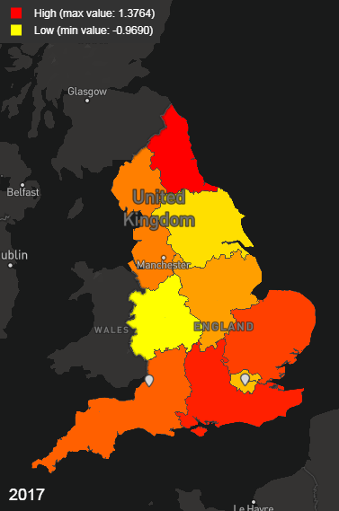

*The figure above shows the Choropleth map of the loneliness zscore in England in 2017 at the regional level. In this representation the darker the color the higher the zcore. To find the zscore of a region the **average** of every zscore reported by every center within the region is computed.*

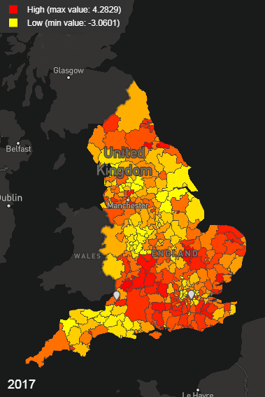

*The figure above shows the Choropleth map of the loneliness zscore in England in 2017 at the county level. In this representation the darker the color the higher the zcore. To find the zscore of a county the **average** of every zscore reported by every center within the region is computed.*

## 1.5 Student migration

In order to visualize the migration of students from abroad to England the following dataset provided by HESA(Higher Education Statistics Agency) was used: https://www.hesa.ac.uk/data-and-analysis/students/table-11 The dataset information on the number of students moving to each English region, the domicile of the students, as well as their mode and level of study between 2014 and 2018.

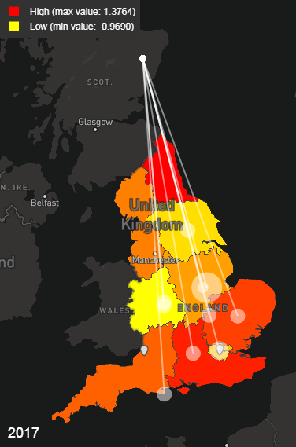

*The figure above shows the migration of all the students from Aberdeenshire to the different region in England for the 2016/2017 academic year.*

Data visualization is an important step which allow a better understanding of any dataset before analysis. Here the data provided is displayed in different form such that a clear view of the data distribution in England is achieved.

# 2 Introduction to analysis

## 2.1 Research question

We choose this question because we believe the effect of student migration on those left behind is often overlooked in terms of analysis/interventions.

## 2.2 Hypotheses

- Is outward migration for education at the county level associated with the mean loneliness score for that county?
- Is outward migration for education at the regional level associated with the mean loneliness score for that region?
- Is total student migration for edcuation (number of students leaving plus number of students arriving) at the regional level associated with the mean loneliness score for that region?

# 3 Datasets

The datasets used in this analysis are laid out below. For familiarity, the first few rows of each datasets are presented.

## 3.1 NSO Lonliness Score

Sourced from the JGI Data Competition team.

| msoa11cd | msoa11nm | msoa11nmw | st_areasha | st_lengths | loneills_2016 | loneills_2017 | loneills_2018 |
| --- | --- | --- | --- | --- | --- | --- | --- |
| E02006534 | Adur 001 | Adur 001 | 6530065 | 16833 | 1.5867 | 1.225 | 1.857 |
| E02006535 | Adur 002 | Adur 002 | 5845402 | 16300 | 2.1739 | 1.905 | 2.042 |
| E02006536 | Adur 003 | Adur 003 | 10594058 | 17615 | 0.8986 | 1.257 | 1.231 |
| E02006537 | Adur 004 | Adur 004 | 2953407 | 15209 | 1.6069 | 1.802 | 2.135 |
| E02006538 | Adur 005 | Adur 005 | 1992233 | 16823 | 1.9869 | 1.920 | 2.255 |
| E02006539 | Adur 006 | Adur 006 | 8296730 | 17177 | 0.4642 | 1.089 | 1.260 |

## 3.2 Student migration for education dataset

Sourced from the [HESA website](https://www.hesa.ac.uk/data-and-analysis/students/where-from), this dataset describes the number of students moving to each region from a given domicile/town.

|  | X4.way.domicile | Domicile | Level.of.study | Mode.of.study | Academic.Year | Region.of.HE.provider | Number |
| --- | --- | --- | --- | --- | --- | --- | --- |
| 19 | All | Aberdeenshire | All | Full-time | 2017/18 | North East | 40 |
| 20 | All | Aberdeenshire | All | Full-time | 2017/18 | North West | 35 |
| 21 | All | Aberdeenshire | All | Full-time | 2017/18 | Yorkshire and The Humber | 25 |
| 22 | All | Aberdeenshire | All | Full-time | 2017/18 | East Midlands | 15 |
| 23 | All | Aberdeenshire | All | Full-time | 2017/18 | West Midlands | 20 |
| 24 | All | Aberdeenshire | All | Full-time | 2017/18 | East of England | 30 |

## 3.3 Town/County/County List

Sourced from [here](https://www.paulstenning.com/uk-towns-and-counties-list/), this dataset matches town names to their respective counties and countries.

| Town | County | Country |
| --- | --- | --- |
| Ampthill | Bedfordshire | England |
| Arlesey | Bedfordshire | England |
| Bedford | Bedfordshire | England |
| Biggleswade | Bedfordshire | England |
| Dunstable | Bedfordshire | England |
| Flitwick | Bedfordshire | England |

## 3.4 County/Region List

Sourced from [here](https://wiki.freecycle.org/UK_Counties_and_Regions), this dataset matches counties to their respective regions.

| County | Region |
| --- | --- |
| Bedfordshire | East |
| Berkshire | South East |
| Bristol | South West |
| Buckinghamshire | South East |
| Cambridgeshire | East |
| Cheshire | West Midlands |

## 3.5 District/County List

Sourced from [here](https://en.wikipedia.org/wiki/List_of_English_districts), this dataset matches districts to their respective counties.

| District | County |
| --- | --- |
| Adur | West Sussex |
| Allerdale | Cumbria |
| Amber Valley | Derbyshire |
| Arun | West Sussex |
| Ashfield | Nottinghamshire |
| Ashford | Kent |

# 4 Preparation for analysis

## 4.1 Create the combined towns, counties and regions dataset

To create a single dataset which matched towns to their respective counties and regions, we merged datasets 3 & 4, on the basis of County name. We also removed country information after limiting the new dataset to towns/counties/regions in England.

```r
# Import town.county list, and limit to towns in England
town.county <- read.csv("data/Towns_List.csv")
town.county <- town.county[which(town.county$Country=="England"),]
town.county <- town.county[,c(1:2)]

# Import county.region list
county.region <- read.csv("data/county.region.csv", stringsAsFactors=FALSE, header = TRUE)
colnames(county.region)[1] <- "County"

# Merge above datasets on the basis of county to create town.county.region data
town.county.region <- merge(town.county, county.region)
```

Top six rows of the town.county.region dataset

| Town | County | Region |
| --- | --- | --- |
| Ampthill | Bedfordshire | East |
| Arlesey | Bedfordshire | East |
| Bedford | Bedfordshire | East |
| Biggleswade | Bedfordshire | East |
| Dunstable | Bedfordshire | East |
| Flitwick | Bedfordshire | East |

## 4.2 Creating complete migration dataset

```r
# Read in HESA student migration
data.move <- read.csv("data/Movement data.csv", header = FALSE)

# Clean dataframe of description and correct column names
data.move <- data.move[18:nrow(data.move),]
colnames(data.move) = make.names(as.character(unlist(data.move[1, ])))
data.move = data.move[-1, ]
data.move <- as_tibble(data.move)

# Remove "City of" from Domicile column to aid merging
data.move <- data.move %>%
  mutate(Domicile = gsub("City of ", "", Domicile))

# Merge on basis of county name
tmp1 <- merge(data.move, county.region, by.x = "Domicile", by.y = "County")
colnames(tmp1)[1] <- "County"

# Merge on basis on town name
tmp2 <- merge(data.move, town.county.region, by.x = "Domicile", by.y = "Town")
tmp2 <- tmp2[,c(2:9)]

# Combine the two merged datasets created above
countydata <- rbind(tmp1, tmp2)
```

Top six rows of the movement for education dataset, with additional information on county and region of origin

| County | Region | Academic.Year | Level.of.study | Mode.of.study | Region.of.HE.provider | Number |
| --- | --- | --- | --- | --- | --- | --- |
| Bristol | South West | 2017/18 | Other undergraduate | Part-time | East of England | 5 |
| Bristol | South West | 2017/18 | Other undergraduate | Part-time | London | 10 |
| Bristol | South West | 2015/16 | All postgraduate | Part-time | Wales | 130 |
| Bristol | South West | 2017/18 | Other undergraduate | Part-time | West Midlands | 25 |
| Bristol | South West | 2015/16 | All postgraduate | Part-time | The Open University in England | 70 |
| Bristol | South West | 2015/16 | All postgraduate | Part-time | Total England | 2265 |

## 4.3 Handling dates

We ran into issues around how to convert the academic year (used in the student migration data) to the calendar year (used in the lonliness index data).

We decided to assign the full effect of a given academic year to it’s earliest calendar year, on the basis that the effect of student migration on lonliness is likely to be most acute in the months immediately after their departure. As an example, the 2014/2015 academic year was recoded as 2014.

```r
countydata <- countydata %>%
  mutate(
  Academic.Year = gsub("2014/15", "2014", Academic.Year),
  Academic.Year = gsub("2015/16", "2015", Academic.Year),
  Academic.Year = gsub("2016/17", "2016", Academic.Year),
  Academic.Year = gsub("2017/18", "2017", Academic.Year)
  )
```

## 4.4 Creating outward migration for education figure at the county level

In keeping with our research question, to prepare the dataset to examine the effect on lonelinenss within a county of students moving out of the country to study, we:

- Removed the totals rows to prevent double counting
- Removed students enrolled in The Open university, as this is primarily a distance learning insitution, and so students would not have to travel to attend this institution.
- Removed students those whose institution was in the same region which they came from. This was used as a proxy for a substantial distance between home county and university.

```r
countydata.trimmed.out <- filter(
  countydata,
  Region.of.HE.provider != "Total England" &
  Region.of.HE.provider != "Total United Kingdom" &
  Region.of.HE.provider != "The Open University in England" &
  Region.of.HE.provider != Region
  )
```

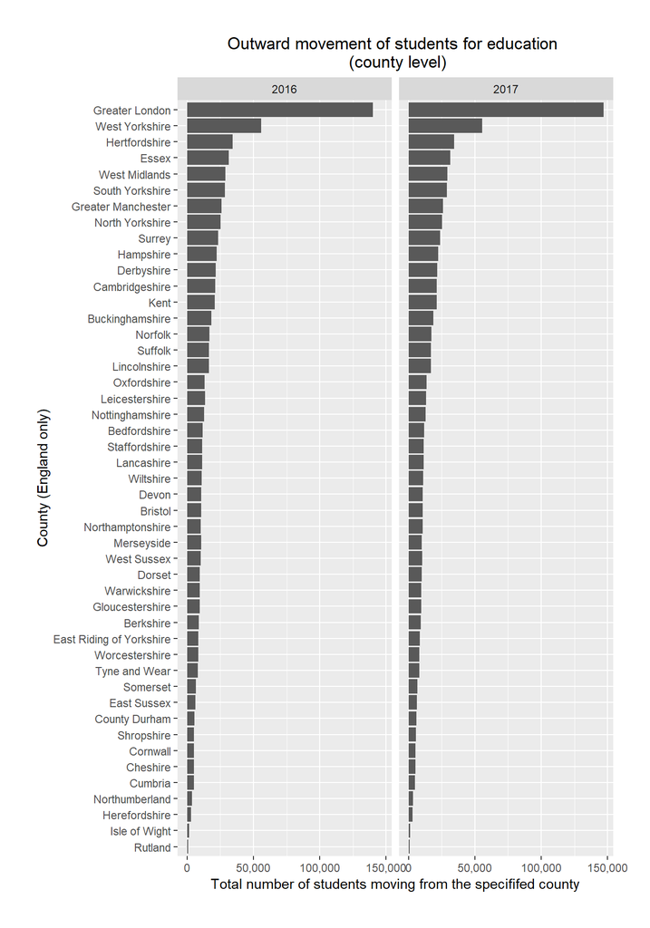

```r
# Create sum of people moving from each county in 2016
data.outof.domicile <- filter(countydata.trimmed.out, X4.way.domicile == "All", Level.of.study == "All", Mode.of.study == "All") %>%
  group_by(Academic.Year, County) %>%
  summarise(sum.no = sum(as.numeric(as.character(Number))))

# Filter data to 2016/2017
fig1.data <- data.outof.domicile[which(data.outof.domicile$Academic.Year=="2016" | data.outof.domicile$Academic.Year=="2017"),]

# Create plot
ggplot(fig1.data, aes(x = reorder(County,sum.no), y=sum.no)) +
  facet_grid(.~Academic.Year) +
  geom_bar(stat="identity") +
  coord_flip() +
  labs(x = "County (England only)",
       y = "Total number of students moving from the specififed county",
       title = "Outward movement of students for education \n (county level)") +
  scale_y_continuous(breaks=seq(0, 175000, 50000),label = scales::comma, expand=c(0.05,0))+
  theme(plot.margin = unit(c(1,1,1,1), "cm"),
        plot.title = element_text(hjust = 0.5))
```

## 4.5 Total change in population per region due to migration for education

We decide to examine the effect of total migration for education (number of students leaving the region plus number of students arriving in the region) on lonliness in that region.

We created a summative rather than net migration for education per region figure on the basis that having students moving into a region is more likely to increase lonliness (as they may be homesick) than reduce it, as they will not keep up the social contacts that the students who left had, plus they might possibly be homesick/lonely themselves.

### 4.5.1 Outward migration for education figure at the region level

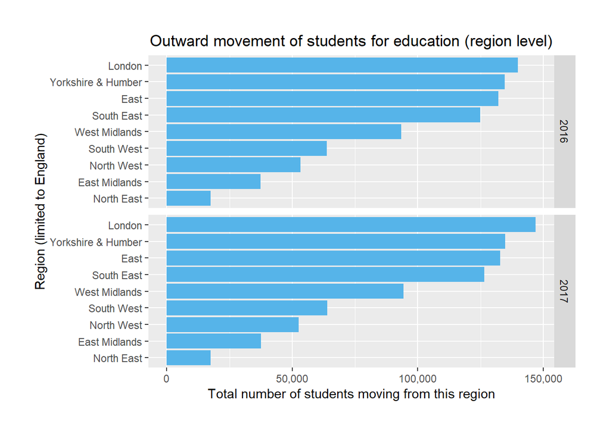

```r
# Building on the intital analysis done above
data.outof.region <- filter(countydata.trimmed.out, X4.way.domicile == "All", Level.of.study == "All", Mode.of.study == "All") %>%
  group_by(Academic.Year, Region) %>%
  summarise(no.out = sum(as.numeric(as.character(Number))))

# Filter data to 2016
data.outof.region.plot <- data.outof.region[which(data.outof.region$Academic.Year=="2016" | data.outof.region$Academic.Year=="2017"),]

# Create plot
ggplot(data.outof.region.plot, aes(x = reorder(Region, no.out), y=no.out)) +
  facet_grid(Academic.Year~.) +
  geom_bar(stat="identity", fill = "#56B4E9") +
  coord_flip() +
  labs(x = "Region (limited to England)",
       y = "Total number of students moving from this region",
       title = "Outward movement of students for education (region level)")+
  scale_y_continuous(label = scales::comma, expand=c(0.05,0)) +
  theme(plot.margin = unit(c(1,1,1,1), "cm"),
        plot.title = element_text(hjust = 0.5))
```

### 4.5.2 Inward migration for education figure at the region level

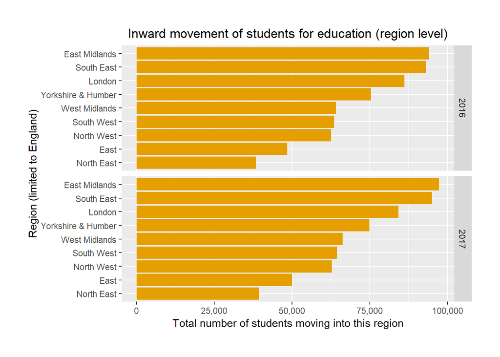

```r
# Limit dataset to those travelling to HE provider within England
countydata.trimmed.in <- countydata

countydata.trimmed.in$Region.of.HE.provider <- as.character(countydata.trimmed.in$Region.of.HE.provider)

countydata.trimmed.in$Region.of.HE.provider <- ifelse(countydata.trimmed.in$Region.of.HE.provider == "East of England","East", countydata.trimmed.in$Region.of.HE.provider)

countydata.trimmed.in$Region.of.HE.provider <- ifelse(countydata.trimmed.in$Region.of.HE.provider == "Yorkshire and The Humber","Yorkshire & Humber", countydata.trimmed.in$Region.of.HE.provider)

countydata.trimmed.in <- filter(
  countydata.trimmed.in,
    Region.of.HE.provider == "West Midlands" |
    Region.of.HE.provider == "Yorkshire & Humber" |
    Region.of.HE.provider == "South West" |
    Region.of.HE.provider == "South East" |
    Region.of.HE.provider == "North West" |
    Region.of.HE.provider == "North East" |
    Region.of.HE.provider == "London" |
    Region.of.HE.provider == "East"|
    Region.of.HE.provider == "East Midlands",
    Region.of.HE.provider != Region
)

countydata.trimmed.in$Region.of.HE.provider <- as.character(countydata.trimmed.in$Region.of.HE.provider)

countydata.trimmed.in$Region.of.HE.provider <- ifelse(countydata.trimmed.in$Region.of.HE.provider == "East of England","East", countydata.trimmed.in$Region.of.HE.provider)

countydata.trimmed.in$Region.of.HE.provider <- ifelse(countydata.trimmed.in$Region.of.HE.provider == "Yorkshire and The Humber","Yorkshire & Humber", countydata.trimmed.in$Region.of.HE.provider)

# Create sum of people moving into each region of England
data.into.region <- filter(countydata.trimmed.in, X4.way.domicile == "All", Level.of.study == "All", Mode.of.study == "All") %>%
  group_by(Academic.Year, Region.of.HE.provider) %>%
  summarise(no.in = sum(as.numeric(as.character(Number))))

colnames(data.into.region)[2] <- "Region"

# Filter data to 2016
data.into.region.plot <- data.into.region[which(data.outof.region$Academic.Year=="2016" | data.outof.region$Academic.Year=="2017"),]

# Create plot
ggplot(data.into.region.plot, aes(x = reorder(Region, no.in), y=no.in), fill = "#56B4E9") +
  facet_grid(Academic.Year~.) +
  geom_bar(stat="identity", fill = "#E69F00") +
  coord_flip() +
  labs(x = "Region (limited to England)",
       y = "Total number of students moving into this region",
       title = "Inward movement of students for education (region level)")+
  scale_y_continuous(label = scales::comma, expand=c(0.05,0)) +
  theme(plot.margin = unit(c(1,1,1,1), "cm"),
        plot.title = element_text(hjust = 0.5))
```

### 4.5.3 Total population change per region (inward + outward migration)

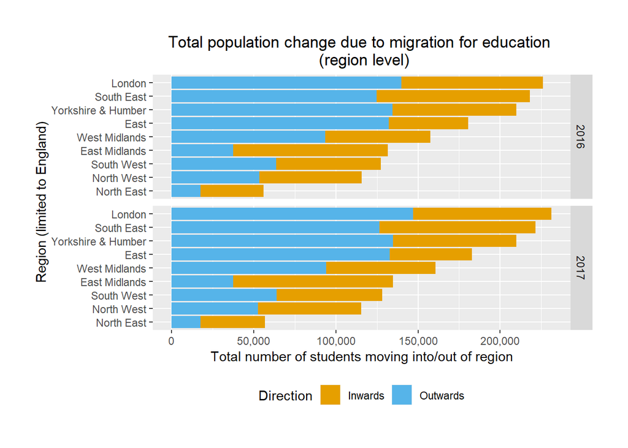

```r
fig2.data.1 <- data.into.region[which(data.outof.region$Academic.Year=="2016" | data.outof.region$Academic.Year=="2017"),]
fig2.data.1[4] <- "Inwards"
colnames(fig2.data.1)[4] <- "Direction"
colnames(fig2.data.1)[3] <- "No"
fig2.data.2 <- data.outof.region[which(data.outof.region$Academic.Year=="2016" | data.outof.region$Academic.Year=="2017"),]
fig2.data.2[4] <- "Outwards"
colnames(fig2.data.2)[4] <- "Direction"
colnames(fig2.data.2)[3] <- "No"

fig2.data <- rbind(fig2.data.1,fig2.data.2)

# Plot results
ggplot(fig2.data, aes(x = reorder(Region,No), y= No, fill = Direction)) +
  facet_grid(Academic.Year~.) +
  geom_bar(stat="identity") +
  coord_flip() +
  labs(x = "Region (limited to England)",
       y = "Total number of students moving into/out of region",
       title = "Total population change due to migration for education \n (region level)") +
  scale_y_continuous(label = scales::comma, expand=c(0.05,0)) +
  scale_fill_manual(values=c("#E69F00", "#56B4E9")) +
  theme(plot.margin = unit(c(1,1,1,1), "cm"),
        legend.position="bottom",
        plot.title = element_text(hjust = 0.5))
```

```r
# Create dataframe of total population chance due to migration
data.sum.migration <- merge(data.into.region, data.outof.region)

data.sum.migration <- data.sum.migration %>%
  mutate(no.total = no.in + no.out)
```

## 4.6 Add county and regional data to loneliness dataset

The final element of pre-analysis preaparation involved adding county and regional data to the loneliness data. This was complicated by the fact that the lonliness dataset presented the loneliness score per district rather than per county. We used the District/County dataset to map districts to their corresponding counties, and subsequently added regional information aswell.

```r
data.lonliness <- read.csv("data/msoa_loneliness.csv")

data.lonliness <- data.lonliness %>%
  mutate(District = gsub('[[:digit:]]+', '', msoa11nm),
         District = gsub(" $","", District, perl=T))

# Add county Level information
district.county <- read.csv("data/district-county.csv")

colnames(district.county)[1] <- "District"

data.lonliness <- merge(data.lonliness,district.county,by="District",all.x=TRUE)

data.lonliness$County <- as.character(data.lonliness$County)

data.lonliness$County <- ifelse(is.na(data.lonliness$County) == TRUE,"0", data.lonliness$County)

data.lonliness$County <- ifelse(data.lonliness$District == "Bournemouth", "Dorset", data.lonliness$County)

data.lonliness$County <- ifelse(data.lonliness$District == "Stockton-on-Tees", "County Durham", data.lonliness$County)

data.lonliness$County <- ifelse(data.lonliness$District == "Poole", "Dorset", data.lonliness$County)

data.lonliness$County <- ifelse(data.lonliness$District == "Christchurch", "Dorset", data.lonliness$County)

data.lonliness$County <- ifelse(data.lonliness$District == "East Dorset", "Dorset", data.lonliness$County)

data.lonliness$County <- ifelse(data.lonliness$District == "West Dorset", "Dorset", data.lonliness$County)

data.lonliness$County <- ifelse(data.lonliness$District == "North Dorset", "Dorset", data.lonliness$County)

data.lonliness$County <- ifelse(data.lonliness$District == "Purbeck", "Dorset", data.lonliness$County)

data.lonliness$County <- ifelse(data.lonliness$District == "Shepway", "Kent", data.lonliness$County)

data.lonliness$County <- ifelse(data.lonliness$District == "St Edmundsbury", "West Suffolk", data.lonliness$County)

data.lonliness$County <- ifelse(data.lonliness$District == "St. Helens", "Merseyside", data.lonliness$County)

data.lonliness$County <- ifelse(data.lonliness$District == "Forest Heath", "West Suffolk", data.lonliness$County)

data.lonliness$County <- ifelse(data.lonliness$District == "Suffolk Coastal", "East Suffolk", data.lonliness$County)

data.lonliness$County <- ifelse(data.lonliness$District == "Waveney", "East Suffolk", data.lonliness$County)

data.lonliness$County <- ifelse(data.lonliness$District == "Taunton Deane", "Somerset West and Taunton", data.lonliness$County)

data.lonliness$County <- ifelse(data.lonliness$District == "West Somerset", "Somerset West and Taunton", data.lonliness$County)

data.lonliness$County <- ifelse(data.lonliness$District == "Weymouth and Portland", "Dorset", data.lonliness$County)

# Add regional information
county.region <- read.csv("data/county.region.csv")
colnames(county.region)[1] <- "County"

data.lonliness <- merge(data.lonliness, county.region, by="County",all.x=TRUE)

data.lonliness$Region <- ifelse(data.lonliness$County == "West Suffolk",  "East", as.character(data.lonliness$Region))

data.lonliness$Region <- ifelse(data.lonliness$County == "East Suffolk",  "East", as.character(data.lonliness$Region))

data.lonliness$Region <- ifelse(data.lonliness$County == "Somerset West and Taunton", "South West", as.character(data.lonliness$Region))
```

# 5 Analysis

## 5.1 Association of number of students leaving county (England only) and mean loneliness score for that county

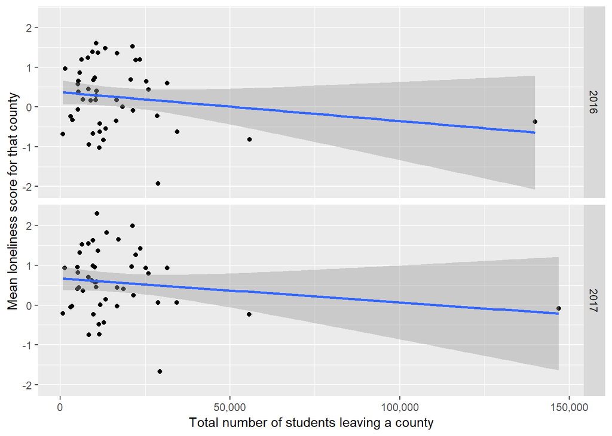

```r
# Summarise by county
mean.lonliness.county <- data.lonliness %>%
  group_by(County) %>%
  summarise("2016" = mean(loneills_2016),
            "2017" = mean(loneills_2017),
            "2018" = mean(loneills_2018))

mean.lonliness.county <- gather(mean.lonliness.county, Academic.Year, mean.score, "2016","2017","2018", factor_key = FALSE)

# Merge with movement data
move.lonliness.county <- merge(mean.lonliness.county, data.outof.domicile)

ggplot(move.lonliness.county, aes(x=sum.no,y=mean.score))+
  facet_grid(Academic.Year~.)+
  geom_point() +
  geom_smooth(method='lm') +
  scale_x_continuous(labels = comma) +
  labs(x = "Total number of students leaving a county",
         y = "Mean loneliness score for that county")
```

```r
move.lonliness.county.2016 <- move.lonliness.county[which(move.lonliness.county$Academic.Year == 2016),]
move.lonliness.county.2017 <- move.lonliness.county[which(move.lonliness.county$Academic.Year == 2017),]

out.county.linearMod.2016 <- lm(mean.score ~ sum.no, data=move.lonliness.county.2016)
out.county.linearMod.2017 <- lm(mean.score ~ sum.no, data=move.lonliness.county.2017)

out.county.p.2016 <- (summary(out.county.linearMod.2016)$coefficients[,4])[2]
out.county.p.2017 <- (summary(out.county.linearMod.2017)$coefficients[,4])[2]
```

The correlation coefficients for 2016 and 2017 were -0.1865 and -0.1645 respectively.

Linear regression showed poor evidence for an association between mean loneliness score per county and the number of students who have left that county for education reasons. The regression coefficient for 2016 was -7.247910^{-6} (p=0.2094) and for 2017 was -6.016110^{-6} (p=0.2692).

## 5.2 Association of number of students leaving region (England only) and mean loneliness score for that region

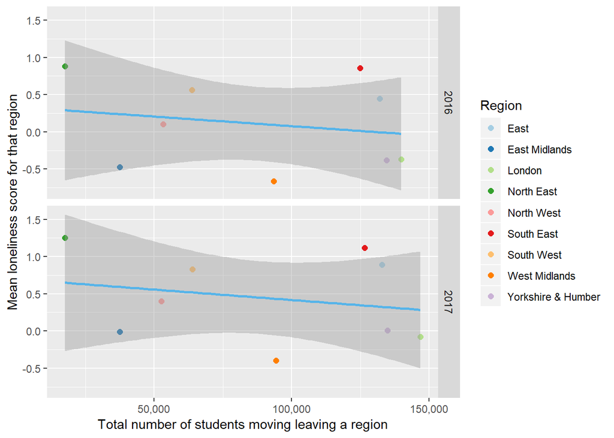

```r
# Summarise by Region
mean.lonliness.region <- data.lonliness %>%
  group_by(Region) %>%
  summarise("2016" = mean(loneills_2016),
            "2017" = mean(loneills_2017),
            "2018" = mean(loneills_2018))

mean.lonliness.region <- gather(mean.lonliness.region, Academic.Year, mean.score, "2016","2017","2018", factor_key = FALSE)

# Merge with movement out of region data
out.move.lonliness.region <- merge(mean.lonliness.region, data.outof.region)

ggplot(out.move.lonliness.region, aes(x=no.out,y=mean.score)) +
  facet_grid(Academic.Year~.) +
  geom_point(aes(colour = Region), size = 2) +
  geom_smooth(method='lm', colour = "#56B4E9") +
  scale_x_continuous(labels = comma) +
  scale_color_brewer(palette="Paired") +
  labs(x = "Total number of students moving leaving a region",
         y = "Mean loneliness score for that region")
```

```r
out.move.lonliness.region.2016 <- out.move.lonliness.region[which(out.move.lonliness.region$Academic.Year == 2016),]
out.move.lonliness.region.2017 <- out.move.lonliness.region[which(out.move.lonliness.region$Academic.Year == 2017),]

out.linearMod.2016 <- lm(mean.score ~ no.out, data=out.move.lonliness.region.2016)
out.linearMod.2017 <- lm(mean.score ~ no.out, data=out.move.lonliness.region.2017)

out.p.2016 <- (summary(out.linearMod.2016)$coefficients[,4])[2]
out.p.2017 <- (summary(out.linearMod.2017)$coefficients[,4])[2]
```

The correlation coefficients for 2016 and 2017 were -0.2008 and -0.2278 respectively.

The linear regression coefficient for 2016 was -2.574310^{-6} (p=0.6045) and for 2017 was -2.81710^{-6} (p=0.5556).

## 5.3 Association of total student migration for education per region (total number leaving region plus total number moving to region) and mean loneliness score for that region (England only)

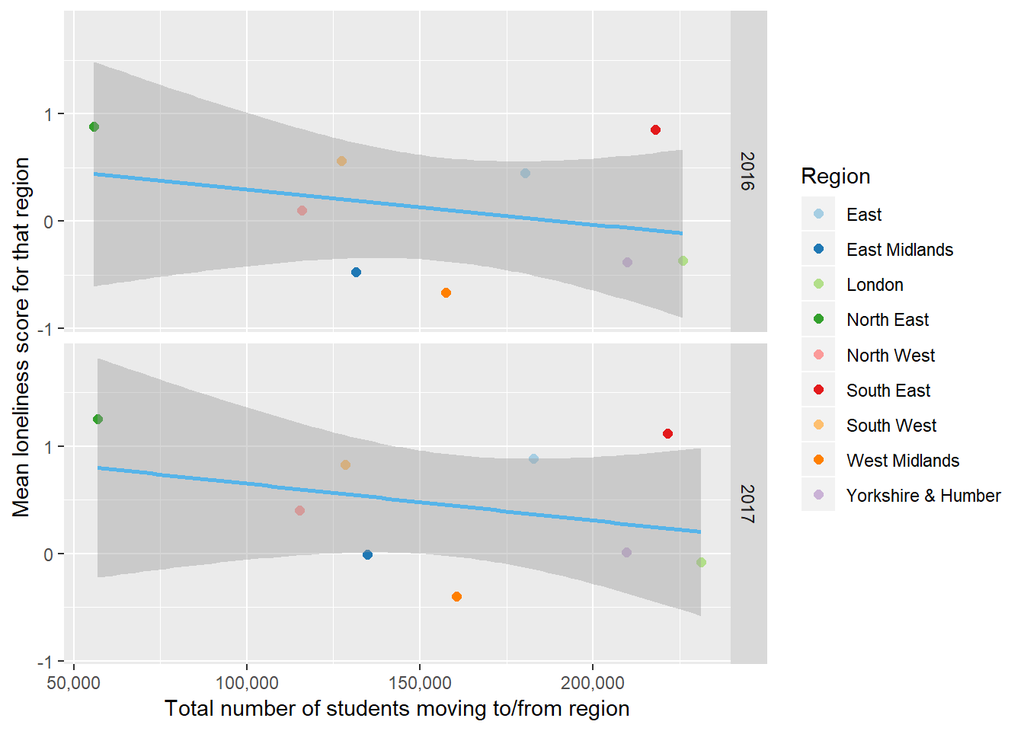

```r
data.sum.migration <- data.sum.migration[,c(1,2,5)]

total.move.lonliness.region <- merge(data.sum.migration, mean.lonliness.region)

ggplot(total.move.lonliness.region, aes(x=no.total,y=mean.score)) +
  facet_grid(Academic.Year~.) +
  geom_point(aes(colour = Region), size = 2) +
  geom_smooth(method='lm', colour = "#56B4E9") +
  scale_x_continuous(labels = comma) +
  scale_color_brewer(palette="Paired") +
  labs(x = "Total number of students moving to/from region",
         y = "Mean loneliness score for that region")
```

```r
total.move.lonliness.region.2016 <- total.move.lonliness.region[which(total.move.lonliness.region$Academic.Year == 2016),]
total.move.lonliness.region.2017 <- total.move.lonliness.region[which(total.move.lonliness.region$Academic.Year == 2017),]

total.linearMod.2016 <- lm(mean.score ~ no.total, data=total.move.lonliness.region.2016)
total.linearMod.2017 <- lm(mean.score ~ no.total, data=total.move.lonliness.region.2017)

total.p.2016 <- (summary(total.linearMod.2016)$coefficients[,4])[2]
total.p.2017 <- (summary(total.linearMod.2017)$coefficients[,4])[2]
```

The correlation coefficients for 2016 and 2017 were -0.3052 and -0.3294 respectively.

The linear regression coefficient for 2016 was -3.25810^{-6} (p=0.4246) and for 2017 was -3.431510^{-6} (p=0.3867).

# 6 Discussion

## 6.1 Limitations

- Had migration data been presented at the district rather than county level, we would have been able to perform the analysis at the district rather than county level. This may have impoved the ability of aour analysis to detect a relationship between the two variables.